# A short introduction to R

2018-12-07

## What is **R**?

## **R** in a nutshell

[figure not shown]

- a free software for data analysis
- an interpreted programming language, derived from `S-plus’
- initially developed by R. Ihaka and R. Gentleman (1996)
- currently developed by the R Core Team (20 people)
- largest collection of tools for data analysis (1,000s of contributors)

## Where can you get it?

[figure not shown]

- The **R** project: www.r-project.org
- archiving / distribution network CRAN:  
  cran.r-project.org/mirrors.html
- available on Windows, MacOSX, Linux

## What can you do with it?

[figure not shown]

- basic statistics: statistical tests, linear modelling, multivariate analysis
- spatial statistics: GIS, mapping, clustering
- graph theory: social sciences, network analysis, graph algorithm
- genetics: phylogenetic trees, genetic markers, genomics
- epidemiology!
- much more: see *task views* cran.r-project.org/web/views/

## What does “free” mean?

[figure not shown]

- Freedom = *ability to make informed decisions*
- you don’t pay for it
- the code is accessible by anyone
- anyone can use, modify and share the code

## Getting started

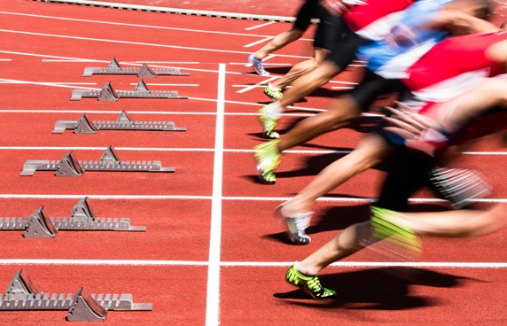

- get **R** for your system (download from CRAN)
- get a Graphical User Interface (GUI): RStudio, emacs + ESS, Tinn-R
- (or at least) get a text editor to write code: notepad++, emacs, vi, Tinn-R, …

## And then…

## Getting help

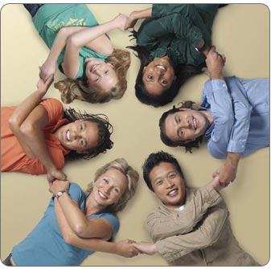

- `?foo` or `help("foo")`: access the help page of `foo`
- `??bar` or `help.search("foo")`: look for `foo` in help pages
- dedicated mailing lists: stat.ethz.ch/mailman/listinfo
- the RECON forum: http://www.repidemicsconsortium.org/forum/
- google

## Storing data in **R**

## How does **R** store information?

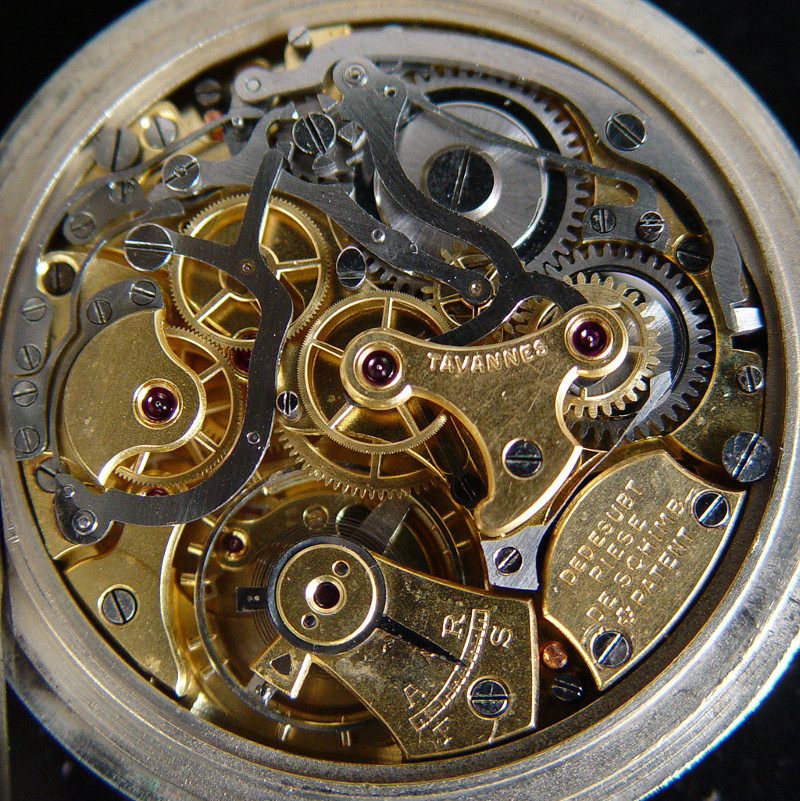

- no files, all in the RAM (i.e. temporary memory)
- data, results, functions, etc. are all **R** *objects*
- one *object* can be saved / loaded using `saveRDS`/`readRDS` (output: `.rds` files)
- several *objects* can be saved / loaded using `save`/`load` (output: `.RData` files)
- an entire session can be saved using `save.image`

## How to create objects?

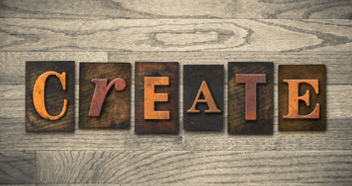

General syntax: `object_name <- content`:

```r
toto <- 1:8
toto # check content: 1, 2, 3, ...
```

```
## [1] 1 2 3 4 5 6 7 8
```

```r
toto <- "some text"
toto # content has changed
```

```
## [1] "some text"
```

## Round numbers: `integer`

```r
a <- 1:10
a
```

```
##  [1]  1  2  3  4  5  6  7  8  9 10
```

```r
class(a)
```

```
## [1] "integer"
```

## Decimal numbers: `numeric`

```r
b <- c(-0.1, 10.123, pi)
b
```

```
## [1] -0.100000 10.123000  3.141593
```

```r
class(b)
```

```
## [1] "numeric"
```

## Text: `character`

```r
a <- c("hello world", "this is fun", "even more fun coming")
a
```

```
## [1] "hello world"          "this is fun"          "even more fun coming"
```

```r
class(a)
```

```
## [1] "character"
```

## Categorical variables: `factor`

```r
a <- factor(c("red", "blue", "green", "red", "green"))
a
```

```
## [1] red   blue  green red   green
## Levels: blue green red
```

```r
class(a)
```

```
## [1] "factor"
```

```r
levels(a)
```

```
## [1] "blue"  "green" "red"
```

## Booleans: `logical`

The `logical` type can be `TRUE` or `FALSE`:

```r
a <- c(TRUE, FALSE, TRUE, TRUE)
a
```

```
## [1]  TRUE FALSE  TRUE  TRUE
```

```r
class(a)
```

```
## [1] "logical"
```

## Vectors

A `vector` stores several values of the same type as a one-dimensional array:

```r
a <- c(1, 2, 10, -1, 1.123)
a
```

```
## [1]  1.000  2.000 10.000 -1.000  1.123
```

```r
length(a)
```

```
## [1] 5
```

## Matrices

A `matrix` stores several values of the same type as a table:

```r
a <- matrix(sample(1:12), ncol = 4)
a
```

```
##      [,1] [,2] [,3] [,4]
## [1,]   12    7    8    4
## [2,]   11   10    2    5
## [3,]    1    6    9    3
```

```r
class(a)
```

```
## [1] "matrix"
```

```r
dim(a)
```

```
## [1] 3 4
```

## Data frames

A `data.frame` is a table where variables (columns) can have different types (equivalent to a spreadsheet):

```r
a <- data.frame(age = c(10, 54, 3), sex = c("m", "f", "m"))
a
```

```
##   age sex
## 1  10   m
## 2  54   f
## 3   3   m
```

```r
class(a)
```

```
## [1] "data.frame"
```

```r
dim(a)
```

```
## [1] 3 2
```

## Lists

A `list` is a collection of objects of any types and sizes, stored as different `slots`:

```r
age <- c(10, 54, 3)
sex <- factor(c("m", "f", "m"))
swab  <- matrix(
  sample(c("+", "-"), replace = TRUE, 10), nrow = 2,
  dimnames = list(NULL, paste("t", 1:5, sep = "")))
x <- list(age = age, gender = sex, swab_results = swab)
```

## Lists (continued)

```r
x
```

```
## $age
## [1] 10 54  3
##
## $gender
## [1] m f m
## Levels: f m
##
## $swab_results
##      t1  t2  t3  t4  t5
## [1,] "+" "+" "-" "+" "+"
## [2,] "+" "+" "+" "-" "+"
```

```r
class(x)
```

```
## [1] "list"
```

```r
length(x)
```

```
## [1] 3
```

## Summary: basic object types`

- `integer`: integer numbers
- `numeric`: decimal numbers
- `character`: character strings
- `factor`: categorical variables
- `vector`: collection of values (1 dimensional array, same type)
- `matrix`: collection of values (table, same type)
- `data.frame`: columns can have different types, but same length (spreadsheet)
- `list`: collection of elements, no restriction of content
- `...`: classes for: DNA sequences, maps, networks, etc.

## Using functions

## What is a function?

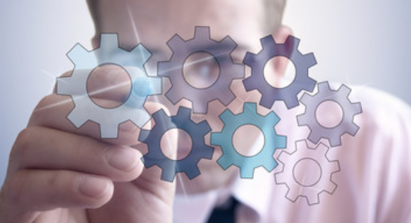

A set of operations made on a given input.

Syntax: `function_name(argument1, argument2, ...)`

Example:

```r
rnorm(8, mean = 5, sd = 3)
```

```
## [1]  2.713883  7.373878  9.364017  1.173302  6.436040  5.624428  7.107626
## [8] -1.727200
```

## How to use a function?

Read the documentation by typing `?function_name`.

Example:

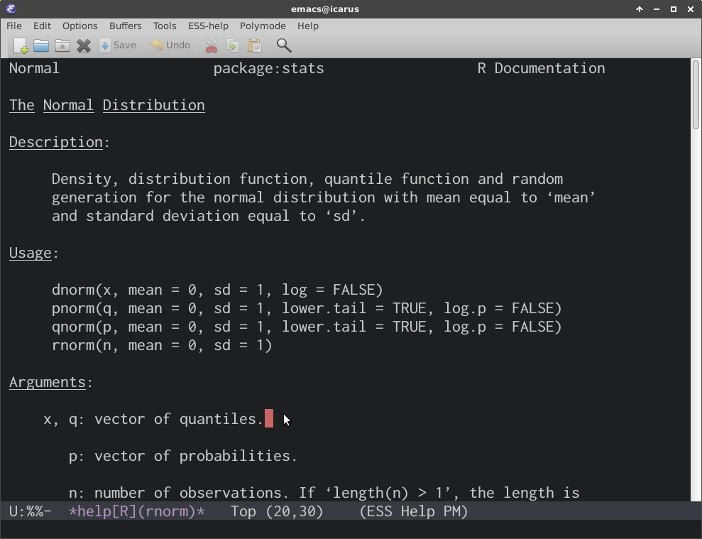

```r
?rnorm
```

## Functions results need storing

For example:

```r
rnorm(5, mean = 3, sd = 2) # this result is not stored
```

```
## [1] -1.133996  7.153785  3.201488  1.897321  1.427742
```

```r
toto <- rnorm(5, mean = 3, sd = 2) # store output in toto
toto
```

```
## [1] -0.04287389  7.92735044  3.46023461  0.21262429  3.52734135
```

## Functions can be nested

For example:

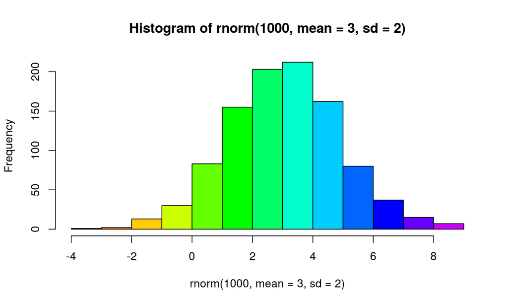

```r
hist(rnorm(1000, mean = 3, sd = 2), col = rainbow(15))
```

## Handling objects

## Subsetting objects

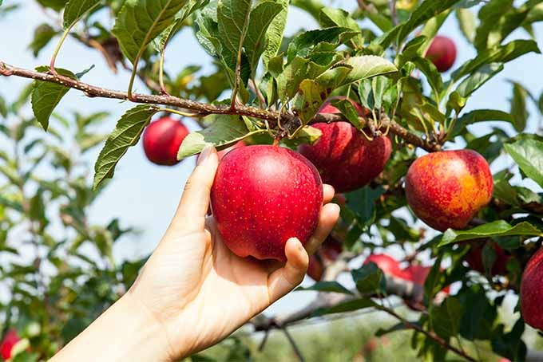

Objects can be subsetted by *index*, *name*, or *logical*, using:

- `object_name[]` for a vector
- `object_name[rows, columns]` for a `matrix` / `data.frame`
- `object_name[[]]` for a `list`

## Subsetting a vector: by index

`x[foo]` where `foo` is an `integer` vector

- positive integers: position of retained entries
- negative integers: position of discarded entries

```r
x <- 10:1
x
```

```
##  [1] 10  9  8  7  6  5  4  3  2  1
```

```r
x[c(1, 2, 5)]
```

```
## [1] 10  9  6
```

```r
letters[2:10]
```

```
## [1] "b" "c" "d" "e" "f" "g" "h" "i" "j"
```

```r
letters[-(1:20)]
```

```
## [1] "u" "v" "w" "x" "y" "z"
```

## Subsetting a vector: logicals

`x[foo]` where `foo` is a `logical` vector, returns the values of `x` where `foo` is `TRUE`:

```r
x <- 1:10
x < 5
```

```
##  [1]  TRUE  TRUE  TRUE  TRUE FALSE FALSE FALSE FALSE FALSE FALSE
```

```r
x[x < 5]
```

```
## [1] 1 2 3 4
```

## Subsetting a vector: names

`x[foo]` where `x` is named and `foo` is a `character` vector of retained names:

```r
x <- sample(1:100, 10)
names(x) <- letters[1:10]
x
```

```
##   a   b   c   d   e   f   g   h   i   j
##  92 100   8  53   7  22  35  49   2  71
```

```r
x[c("c", "d", "a", "i")]
```

```
##  c  d  a  i
##  8 53 92  2
```

## Subsetting and replacing values

`x[foo] <- new.value` where `x[foo]` are values to be replaced with `new.value`:

```r
x <- round(rnorm(14), 2)
x
```

```
##  [1] -1.32  0.12 -0.78  0.68  1.52 -0.06  0.95 -1.97  1.33 -1.42 -0.40
## [12]  2.35 -0.05  0.88
```

```r
x[x< 0] <- 0
x
```

```
##  [1] 0.00 0.12 0.00 0.68 1.52 0.00 0.95 0.00 1.33 0.00 0.00 2.35 0.00 0.88
```

## Subsetting matrices and data frames

Same principle, with `x[lines, columns]`:

```r
x <- matrix(1:15, nrow = 3)
x
```

```
##      [,1] [,2] [,3] [,4] [,5]
## [1,]    1    4    7   10   13
## [2,]    2    5    8   11   14
## [3,]    3    6    9   12   15
```

```r
x[c(3,1), ]
```

```
##      [,1] [,2] [,3] [,4] [,5]
## [1,]    3    6    9   12   15
## [2,]    1    4    7   10   13
```

```r
x[2, 4:5]
```

```
## [1] 11 14
```

## Subsetting lists

`x[foo]` to return a list, `x[[foo]]` for a single element:

```r
x <- list(a = rnorm(4), hi = "Hello", stuff = letters[1:10]); x
```

```
## $a
## [1] -0.03960258  1.20769218 -0.64288920  1.63578167
##
## $hi
## [1] "Hello"
##
## $stuff
##  [1] "a" "b" "c" "d" "e" "f" "g" "h" "i" "j"
```

```r
x[c(1,3)]
```

```
## $a
## [1] -0.03960258  1.20769218 -0.64288920  1.63578167
##
## $stuff
##  [1] "a" "b" "c" "d" "e" "f" "g" "h" "i" "j"
```

```r
x[[3]]
```

```
##  [1] "a" "b" "c" "d" "e" "f" "g" "h" "i" "j"
```

```r
x$stuff
```

```
##  [1] "a" "b" "c" "d" "e" "f" "g" "h" "i" "j"
```

## Using logical operations

## Logical operations 1/4

```r
a <- c(TRUE, TRUE, FALSE, FALSE)
b <- c(TRUE, FALSE, TRUE, FALSE)
rbind(a,b)
```

```
##   [,1]  [,2]  [,3]  [,4]
## a TRUE  TRUE FALSE FALSE
## b TRUE FALSE  TRUE FALSE
```

```r
a & b # logical 'AND'
```

```
## [1]  TRUE FALSE FALSE FALSE
```

```r
a | b # logical 'OR'
```

```
## [1]  TRUE  TRUE  TRUE FALSE
```

## Logical operations 2/4

```r
!a # not A
```

```
## [1] FALSE FALSE  TRUE  TRUE
```

```r
any(a) # at least one TRUE
```

```
## [1] TRUE
```

```r
all(a) # all TRUE
```

```
## [1] FALSE
```

```r
which(a) # indices of the TRUEs
```

```
## [1] 1 2
```

## Logical operations 3/4

`is.na` is useful to spot missing data (NAs)

```r
a <- c(3,NA,2,5,NA,10)
is.na(a)
```

```
## [1] FALSE  TRUE FALSE FALSE  TRUE FALSE
```

```r
a[!is.na(a)]
```

```
## [1]  3  2  5 10
```

## Logical operations 4/4

Logicals are numbers: `TRUE = 1`, `FALSE = 0`

```r
a <- -10:5
sum(a > 0)
```

```
## [1] 5
```

```r
mean(a > 0)
```

```
## [1] 0.3125
```

```r
a * (a > 0)
```

```
##  [1] 0 0 0 0 0 0 0 0 0 0 0 1 2 3 4 5
```

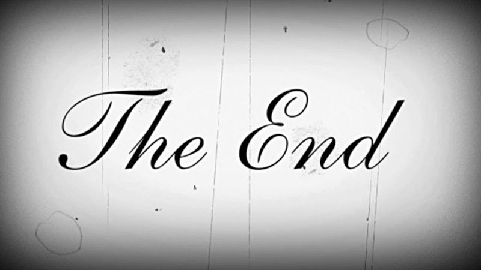